# Final Exam

# 3. Discrete Distributions

Suppose the yearly hospital charges (in thousands of dollars) for a randomly selected Vanderbilt student is a mixture distribution.

For 50% of students, the hospital charges will be $0. For the remaining 50% of students, the hospital charges are a random variable described by a gamma distribution with shape = 2 and scale = 2. (Again, in thousands of dollars.)

```r
hospital_charges <- function(N){
  group <- rbinom(N, 1, 0.5)
  charges <- 0*group + rgamma(N, shape = 2, scale = 2)*(1-group)
  charges
}
```

**C**. What is the 90th percentile for yearly hospital charges for a randomly selected Vanderbilt student?

```r
out <- NA
for (i in (1:5000)){
  trial <- hospital_charges(5000)
  out[i] <- quantile(trial, 0.9)
}

mean(out)
```

```
## [1] 5.986404
```

**B**. Consider the **class** average yearly hospital charge for the students in a class of size 30. Plot the density function or a simulated histogram of the class average yearly hospital charge.

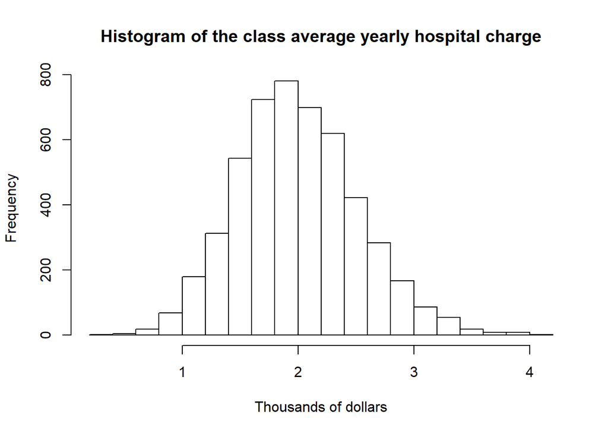

```r
out <- NA
for (i in (1:5000)){
  trial <- hospital_charges(30)
  out[i] <- mean(trial)
}

hist(out, main = "Histogram of the class average yearly hospital charge", xlab = "Thousands of dollars")
```

**A**. What is the probability that a randomly selected class of size 30 students will have less than 10 students with zero yearly hospital charges?

```r
total = 0

for (j in (1:5000)){
  cnt = 0
  for (i in (1:30)){
    res <- hospital_charges(1)
    if (res == 0){
    cnt = cnt + 1
    }
  }
  if (cnt < 10) {
    total = total + 1
  }
}

total/5000
```

```
## [1] 0.0212
```

# 4. Continuous Distributions

**C.** Suppose diastolic blood pressure (DBP) follows a normal distribution with mean 80 mmHg and SD 15 mmHg. What is the probability that a randomly sampled person’s DBP lies between 70 and 104 mmHg?

```r
pnorm(104, mean = 80, sd = 15) - pnorm(70, mean = 80, sd = 15)
```

```
## [1] 0.6927082
```

`answer:` p = 0.6927

**B.** Suppose a human femur was discovered that is 37 cm long. Also suppose that using the NHANES data, researchers believe the distribution of femor bones, by sex, are distributed as follows:

- Female adult femor $\sim N(36, 3.3)$
- Male adult femor $\sim N(40, 3.4)$

Under the assumption that male and females are equally likely, what is the probability that the discovered femor was from a male?

```r
# bayes rule: P(A|B) = P(B|A)P(A)/(P(B|A)P(A) + P(B|~A)P(~A))

dnorm(37,40,3.4)*0.5 /((dnorm(37,40,3.4)*0.5) + (dnorm(37,36,3.3)*0.5))
```

```
## [1] 0.407765
```

```r
# 0.407765
```

`answer:` p = 0.408.

**A.** Continuing part **B**, generate a plot of P(femor from male | femor length = x). Let femor length range from 25 to 50.

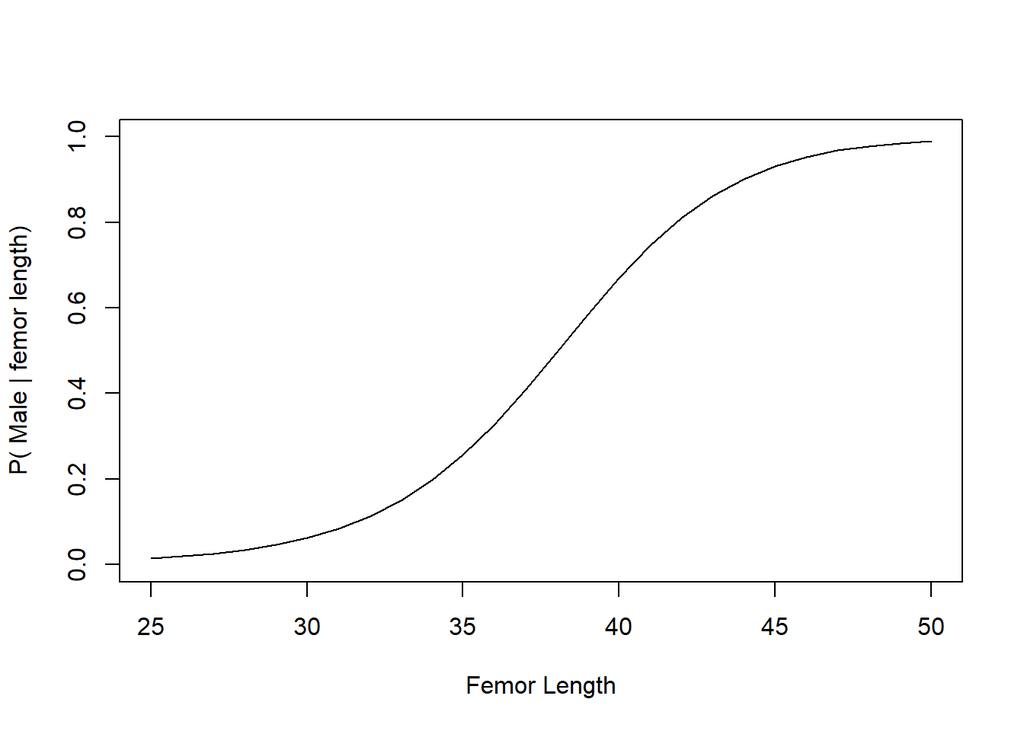

```r
femor_length <- 25:50
prob_male <- dnorm(femor_length,40,3.4)*0.5 /((dnorm(femor_length,40,3.4)*0.5) + (dnorm(femor_length,36,3.3)*0.5))

plot.new()
plot.window(xlim = c(25,50), ylim = c(0,1))
lines(femor_length, prob_male)
axis(1)
axis(2)
box()
title(xlab = "Femor Length", ylab = "P( Male | femor length)")
```

# 5. Expectation and Variance

Let us revisit the yearly hospital charges distribution from a previous section.

> **Recall:** The yearly hospital charges (in thousands of dollars) for a randomly selected Vanderbilt student is a mixture distribution. For 50% of students, the hospital charges will be $0. For the remaining 50% of students, the hospital charges are a random variable described by a gamma distribution with shape = 2 and scale = 2. (Again, in thousands of dollars.)

```r
hospital_charges <- function(N){
  group <- rbinom(N, 1, 0.5)
  charges <- 0*group + rgamma(N, shape = 2, scale = 2)*(1-group)
  charges
}
```

**C.** What is E[yearly hospital charges]?

```r
mean(hospital_charges(10000))
```

```
## [1] 1.993409
```

**B.** Suppose Vanderbilt implements a cap of $10,000 on yearly student hospital charages. What is the mean yearly hospital charge under the new policy?

```r
out <- 0

for (i in (1:100000)){
  one_time <- hospital_charges(1)
  if (one_time > 10){
    one_time = 10
  }
  out <- out + one_time
}

mean(out)/100000
```

```
## [1] 1.961388
```

`answer:` E[yearly hospital charges in new policy] = 1.96 (thousands of dollors).

**A.** What is the variance of yearly hospital charge under the new policy?

```r
# method1: Var(X)=E((X???E(X))^2)
var <- 0
for (i in (1:100000)){
  one_time <- hospital_charges(1)
  if (one_time <= 10) {
  var <- var + (one_time - 1.96)^2
  } else if (one_time > 10){
    var <- var + (10 - 1.96)^2
  }
}
var/100000
```

```
## [1] 7.036698
```

```r
# method2: var(x) = E(x^2) - E(x)^2
```

# 6. Transformations & Sampling Distributions

**C.** Consider the log normal distribution. If X is a log normal random variable, then log(X) is a normal random variable. One way to create pseudo-random draws from the log normal distribution is to generate draws from a normal distribution and then to transform the draws by expononentiating. The parameters of the log normal distribution are the parameters of the underlying normal distribution, $\mu$ and $\sigma$ (or $\sigma^2$).

Log normal data are prevalent is biological systems and econometrics.

Suppose a blood chemistry measure has a log normal distribution with $\mu$ = 0 and $\sigma$ = 1. Generate an histogram or density curve for the sampling distribution of the median when the sample size is 101.

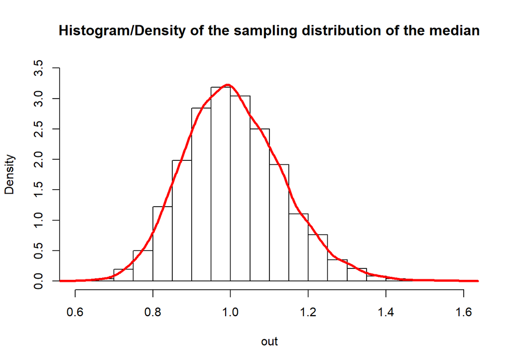

```r
out <- NA
for (i in 1:5000){
  out[i] <- rlnorm(101, 0, 1) %>% median
}

hist(out, prob = T, main= "Histogram/Density of the sampling distribution of the median", ylim = c(0, 3.5))
lines(density(out), col = "red", lwd = 3)
```

**B.** Below is the CDF function for the kth order statistic when the underlying distribution is log normal with $\mu$ = 0 and $\sigma$ = 1. Create a plot of the ECDF of the simulated sampling distribution generated in **C** and overlay the CDF using the function below.

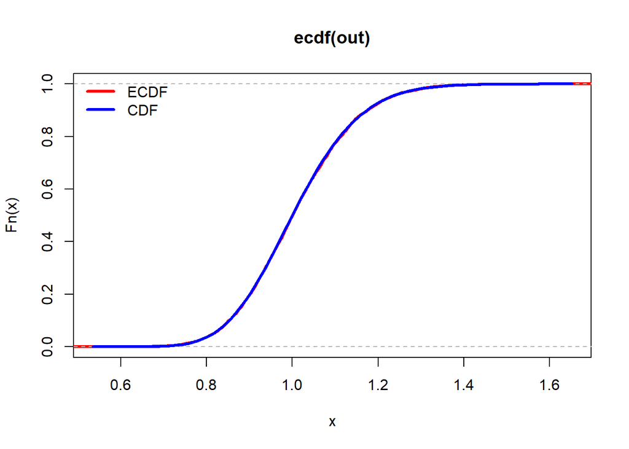

```r
Fk <- function(x,k,n){
  pbinom(k-1, n, plnorm(x), lower.tail = FALSE)
}

m <- ecdf(out)

plot(m, do.points = FALSE, col = "red", lwd = 3)
curve(Fk(x, 51, 101), add =T, col = "blue", lwd = 3)
legend(
    "topleft"
  , c("ECDF","CDF")
  , lwd = 3
  , col = c("red","blue")
  , bty = "n"
)
```

**A.** Of the 25th, 50th, and 75th quantiles of the distribution from **B**, which will have the tighest 95% CI? (Show the sampling distribution of each.)

```r
# Simulation method
out1 <- NA
out2 <- NA
out3 <- NA
for (i in 1:5000){
  sample <- rlnorm(101, 0, 1)
  out1[i] <- quantile(sample, 0.25)
  out2[i] <- quantile(sample, 0.5)
  out3[i] <- quantile(sample, 0.75)

}

quantile(out1, c(0.05/2, 1-0.05/2))
```

```
##      2.5%     97.5%
## 0.3932331 0.6656597
```

```r
quantile(out2, c(0.05/2, 1-0.05/2))
```

```
##      2.5%     97.5%
## 0.7849251 1.2831870
```

```r
quantile(out3, c(0.05/2, 1-0.05/2))
```

```
##     2.5%    97.5%
## 1.489823 2.513592
```

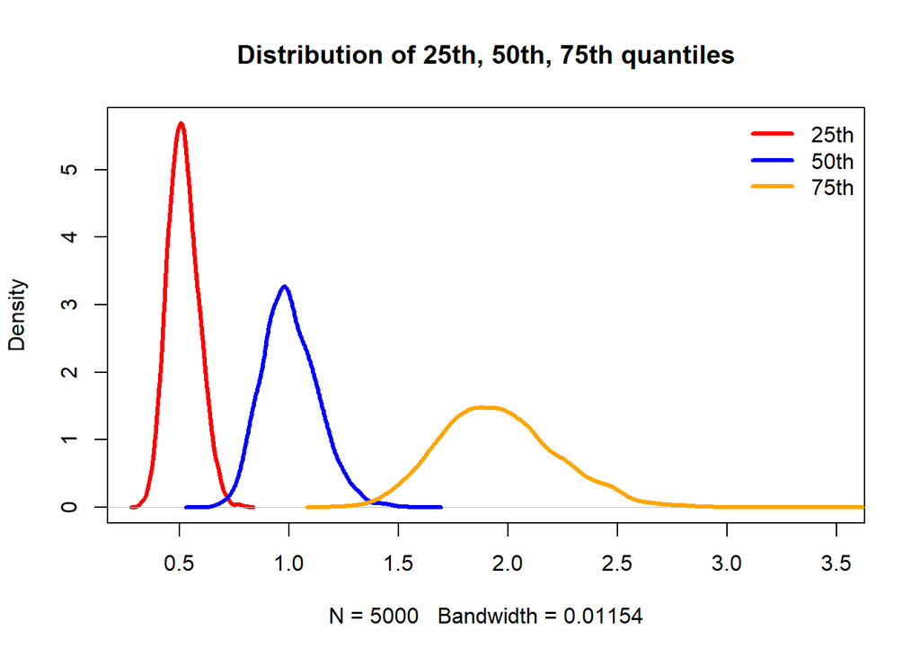

```r
plot(density(out1), col = "red", xlim = c(0.3, 3.5), lwd = 3, main = "Distribution of 25th, 50th, 75th quantiles")
lines(density(out2), col = "blue", lwd = 3)
lines(density(out3), col = "orange", lwd = 3)
legend(
    "topright"
  , c("25th","50th", "75th")
  , lwd = 3
  , col = c("red","blue", "orange")
  , bty = "n"
)
```

# 7. Estimation of CDF and PDF from data

The following code will load the NHANES data and select the first 500 rows.

```r
Hmisc::getHdata(nhgh)
d1 <- nhgh[1:500,]
```

**C.** Estimate the distribution of standing height for adult (age > 18) males using the MLE method with a normal distribution. Create a plot of the estimated density function.

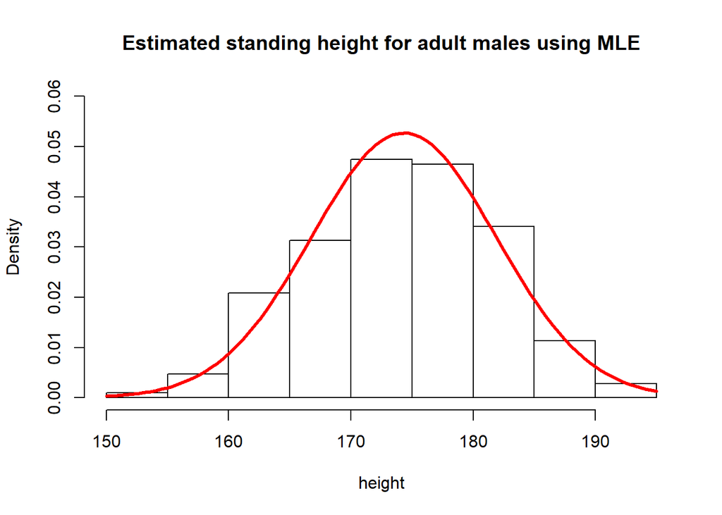

```r
# in normal distribution, MLE is the mean and sd of the variable
ht_male <- d1 %>%
  filter(age > 18) %>%
  filter(sex == "male") %>%
  pull(ht)
mean_mle <- mean(ht_male)
sd_mle <- sd(ht_male)


hist(ht_male, freq = FALSE, ylim = c(0, 0.06), main = "Estimated standing height for adult males using MLE", xlab = "height")
curve(dnorm(x, mean_mle, sd_mle), add = TRUE, lwd = 3, col = "red")
```

**B.** Estimate the distribution of BMI for adult (age > 18) females using using the method of moment method with the gamma distribution. Create a plot of the estimated density function.

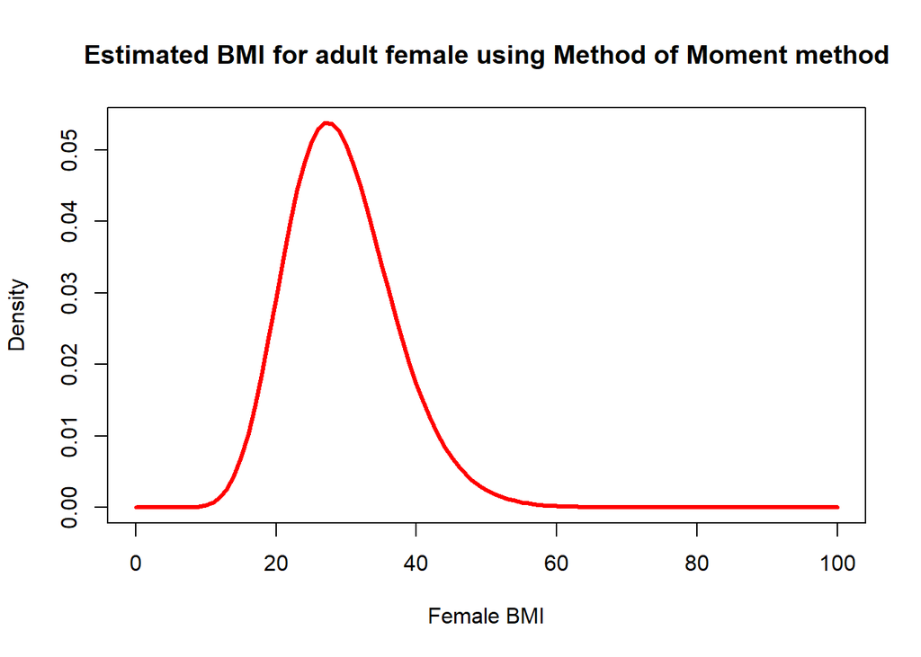

```r
bmi_female <- d1 %>%
  filter(age > 18) %>%
  filter(sex == "female") %>%
  pull(bmi)

xbar <- mean(bmi_female)
s2 <- var(bmi_female)

shape_hat <- xbar^2/s2
scale_hat <- s2/xbar


curve(dgamma(x, shape = shape_hat, scale = scale_hat), xlim = c(0, 100), col = "red", lwd = 3, main = "Estimated BMI for adult female using Method of Moment method", ylab = "Density", xlab = "Female BMI")
```

**A.** Estimate the distribution of creatinine (SCr) for adults (age > 18) using the kernel density method with a gaussian kernel. Create a plot of the estimated density function.

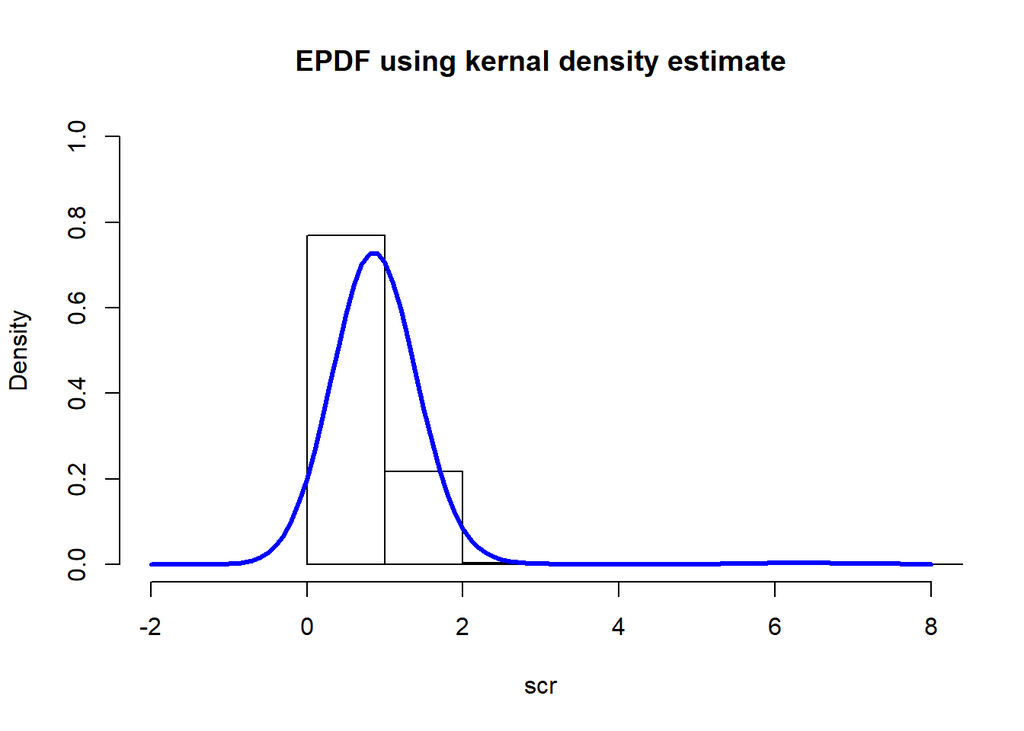

```r
scr <- d1 %>%
  filter(age > 18) %>%
  filter(!is.na(SCr)) %>%
  pull(SCr)

# f^     density function
epdfstar <- function(t, data, smooth){
  outer(t, data, function(a,b){ dnorm(a, b, smooth)}) %>% rowMeans
}

hist(scr, main = "EPDF using kernal density estimate", freq = FALSE, xlim = c(-2, 8), ylim = c(0, 1))
curve(epdfstar(x, scr, smooth = 0.5), add = TRUE, lwd = 3, col = "blue")
```

```r
# second way: defaul density function

# den1 <- density(scr, adjust = 1.5, kernel = "gaussian")
# lines(den1, lwd = 3, col = "red")
```

# 8. Sample from an estimated distribution

The following code will load the low birth weight data from the MASS package. The description of the variables in the dataset can be found in the birthwt documentation with the command `?MASS::birthwt`.

```r
bwt <- MASS::birthwt
```

**C.** Generate a 95% confidence interval for the mean birthweight of infants whose mothers **did** smoke during pregnancy using the bootstrap.

```r
sm <- bwt %>%
  filter(smoke == 1) %>%
  filter(!is.na(bwt)) %>%
  pull(bwt)
# bootstrap

R <- 5000
out <- rep(NA, R)
for (i in 1:R){
  out[i] <- sample(sm, length(sm), replace = T) %>% mean
}

quantile(out, c(0.05/2, 1-0.05/2))
```

```
##     2.5%    97.5%
## 2619.221 2918.761
```

**B.** Generate a 95% confidence interval for the mean birthweight of infants whose mothers **did** smoke during pregnancy using the Central Limit Theorem shortcut.

```r
# t.test
t.test(sm, data = bwt)
```

```
##
##  One Sample t-test
##
## data:  sm
## t = 36.149, df = 73, p-value < 2.2e-16
## alternative hypothesis: true mean is not equal to 0
## 95 percent confidence interval:
##  2619.094 2924.744
## sample estimates:
## mean of x
##  2771.919
```

```r
# by hand

mean_bwt <- mean(sm)
std_bwt <- sd(sm)
N <- length(sm)

Z1 <- -1.96
Z2 <- 1.96

ci_left <- Z1 * (std_bwt/sqrt(N)) + mean_bwt
ci_right <- Z2 * (std_bwt/sqrt(N)) + mean_bwt

ci_left
```

```
## [1] 2621.624
```

```r
ci_right
```

```
## [1] 2922.214
```

`answer:` the 95% CI is [2621.624, 2922.214]

**A.** Let $\mu_s$ be the mean birthweight of infants whose mothers smoked during pregnancy. Let $\mu_{ns}$ be the mean for the non-smoking group. Use simulation to calculate the 95% confidence interval for $\mu_s/\mu_{ns}$.

```r
nonsm <- bwt %>%
  filter(smoke == 0) %>%
  filter(!is.na(bwt)) %>%
  pull(bwt)


out <- NA
for (i in 1:1000){
  out1 <- sample(sm, length(sm), replace = T) %>% mean
  out2 <- sample(nonsm, length(nonsm), replace = T) %>% mean

  out[i] <- out1/out2
}

quantile(out, c(0.05/2, 1-0.05/2))
```

```
##      2.5%     97.5%
## 0.8429023 0.9735176
```

# 9. Inference

**C.** Suppose two studies were performed looking at the risk of mild complication after hernia repair using open and laparoscopic surgical approaches. The study results are below. Using the data from each study individually, perform the hypothesis test that the risk of complication between open and laparoscopic repairs are the same under the usual point null. What is the p-value from each study? What do you conclude from each study?

| Study 1 | Comp | No comp |
| --- | --- | --- |
| Open | 30 | 70 |
| Lap | 35 | 65 |

| Study 2 | Comp | No comp |
| --- | --- | --- |
| Open | 600 | 1400 |
| Lap | 619 | 1381 |

```r
prop.test(c(30, 35), c(30+70, 35+65))
```

```
##
##  2-sample test for equality of proportions with continuity
##  correction
##
## data:  c(30, 35) out of c(30 + 70, 35 + 65)
## X-squared = 0.36467, df = 1, p-value = 0.5459
## alternative hypothesis: two.sided
## 95 percent confidence interval:
##  -0.18963943  0.08963943
## sample estimates:
## prop 1 prop 2
##   0.30   0.35
```

```r
prop.test(c(600, 619), c(600+1400, 619+1381))
```

```
##
##  2-sample test for equality of proportions with continuity
##  correction
##
## data:  c(600, 619) out of c(600 + 1400, 619 + 1381)
## X-squared = 0.3823, df = 1, p-value = 0.5364
## alternative hypothesis: two.sided
## 95 percent confidence interval:
##  -0.03852774  0.01952774
## sample estimates:
## prop 1 prop 2
## 0.3000 0.3095
```

**B.** Suppose that prior to the studies, the researchers established an equivalence threshold of 6 percentage points. Using the confidence intervals, which studies (if any) showed a conclusive similarity between surgical approaches for the complication rate. Explain why.

`answer:` The second study showed a conclusive similarity between surgical approaches for the complication rate. Because we can find that 95% CI in first study is [-0.190, 0.090] while in the second study is [-0.039, 0.020]. The lengths in the two invervals are 0.280 and 0.059, respectively. Thus, the second inverval is inside of the 6 percentage points, which means that it shows a conclusive similarity in this way.

**A.** If the data from the studies were combined, what is the smallest equivalence threshold that would identify a conclusive similarity between the surgical approaches?

```r
res <- prop.test(c(630, 654), c(630+1470, 654+1446))

threshold <- res$conf.int[2] - res$conf.int[1]
threshold
```

```
## [1] 0.05668084
```

`answer:` The smallest equivalence threshold should be 5.67 percentage points

# 10. Joint Distributions

**C.** Fill in the blank. The sample correlation is a measure of ____`linear`___ association.

**B.** Explain why predictions from a conditional distribution generally have smaller prediction error than predictions from the marginal distribution.

`answer:` If two variable are correlated, conditional distribution has less variance than marginal, so we can predict it with less error. If two variable are not correlated, then conditional distribution has no advantage than marginal in prediction.

Let’s look at MSE (MSE = VAR + BIAS^2). If the marginal model and the conditional model both have zero bias, then the difference in MSE comes does to variance. The variance of the conditional model is less than or equal to the variance of the marginal model. This means that the MSE of the conditional model will be less than or equal to the MSE of the marginal model.

**A.** Use the CLT shortcut to calculate the 95% confidence interval for the correlation of arm circumferance and arm length using the NHANES dataset. Is the sample correlation a reasonable measure of association for this data?

```r
#short cut
Hmisc::getHdata(nhgh)

df <- nhgh

cor.test(df$armc, df$arml)
```

```
##
##  Pearson's product-moment correlation
##
## data:  df$armc and df$arml
## t = 46.838, df = 6601, p-value < 2.2e-16
## alternative hypothesis: true correlation is not equal to 0
## 95 percent confidence interval:
##  0.4811147 0.5173282
## sample estimates:
##       cor
## 0.4994396
```

`answer:` Our null hypothesis is that the arm circumferance and arm length has no correlation. Using the cor.test (CLT short cut), we can find that the sample estimated correlation between arm circumferance and arm length is 0.50. Because 0 is not in the 95% CI (0.48, 0.52) and p-value is smaller than 0.05, we can conclude that, in the alpha = 0.05 level, we reject the null, which means that the sample correlationa is a reasonable measure of association for this data.